# 備忘録

### 0919

#### 7種ゲノムでヘッダー修正後の系統樹作成

結果は`~/tools/for_ASTRAL/Astral/240919_7sp`に保存した。

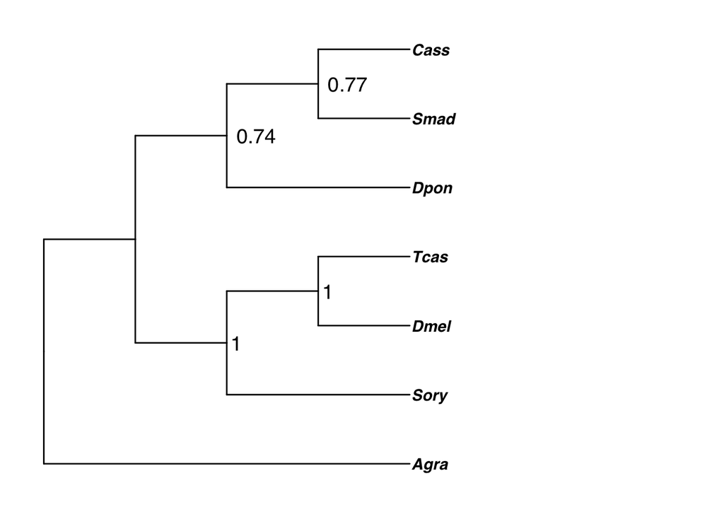

```r
tree10= read.tree("/Users/kosukesano/bio/240919_7sp")
p=ggtree(tree10,  branch.length = 'none')+
  xlim(0,7)+
  theme(text = element_text(face = "italic"))+
  geom_tiplab(fontface = 4, linesize=3.0) + # Make tip labels italic
  geom_nodelab(hjust = -0.2, node = "internal", size = 5) +
  #geom_text(aes(label=node), hjust=-.2)+
  theme_tree()
p
```

結局変わらなかった

#### 7種でのSuperMatrix法による`IQ-TREE`を使った系統樹推定

`~/tools/for_orthofinder/Smad_Agra_Cass_Dpon_Sory_Tcas_Dmel_fasta_dir/OrthoFinder/Results_Sep03/ManualPhylo_data`で`makerun.py`を作成。

```bash
### makerun.pyの中身


import glob
import os

list = []
for i in glob.glob('*.maffted.trimed.edit.fa'):
        list.append(os.path.split(i)[1].rstrip())

#print(list[0])


##ls | grep "maffted.trimed.edit.fa" > otamesi.txtで、完成したOGをotamesi.txtに一行ずつ保存
##ファイルの行数をカウント。このカウント数がfor文のrangeに入る数になる

f = open("run.nex", "w")
f.write("#nexus" + "\n")
f.write("begin sets;" + "\n")
character = "charset part"
for line, i in zip(list, range(4997)):
        row = character + str(i+1) + " = " + line + ": ;"
        f.write("\t" + row + "\n")
f.write("end;" + "\n")
f.close()
```

これで`run.nex`を作る。

続いて`IQ-TREE`の実行。使ったシェルスクリプトは`manualphylo.sh`

```bash
### manualphylo.shの中身

#$ -S /bin/bash
#$ -cwd
#$ -l intel
#$ -pe def_slot 16

date
singularity exec -e /usr/local/biotools/i/iqtree:2.3.3--h21ec9f0_0 iqtree2 -sp run.nex -nt AUTO -bb 1000 -cptime 600
date
```

これを`qsub`で投げた。

##### 7種での欠失を１つ許した`ASTRAL`

`~/tools/for_orthofinder/Smad_Agra_Cass_Dpon_Sory_Tcas_Dmel_fasta_dir/OrthoFinder/Results_Sep03/Orthogroups`下で`SCOwiith0tyusyutu.py`を作成、実行した。`SCOwiith0tyusyutu.py`は0905の完全コピー。

続いて`~/tools/for_orthofinder/Smad_Agra_Cass_Dpon_Sory_Tcas_Dmel_fasta_dir/OrthoFinder/Results_Sep03/SCOwithOneZero_Manualphylo_data`で`Manualphylo_1.py`を実行した。`Manualphylo_1.py`は以下の通り。

```bash
### Manualphylo_1.pyの中身

##analysis_manual.pptxの#46も参照

##AFTER you made MSA file(all_seq.fa) in DDBJ with makeMSA.sh

##時間は10secほど

import numpy as np
import pandas as pd
import os

path = "~/tools/for_orthofinder/Smad_Agra_Cass_Dpon_Sory_Tcas_Dmel_fasta_dir/OrthoFinder/Results_Sep03/"
withpath = "../"

OGs = pd.read_table(path + "Orthogroups/Orthogroups.tsv")

##with openは相対パスしか受け付けないらしい
new = pd.DataFrame()
with open(withpath + "Orthogroups/Orthogroups.GeneCount.SingleCopyWithOneZeroOrtholog.txt", "r")            as fin:
        for line in fin:
                li = line.rstrip()
                new = pd.concat([new, OGs[OGs["Orthogroup"] == li]])
print(new)
new.to_csv(path + "SCOwithOneZero_Manualphylo_data/OG_list.txt", sep = " ", index = False, header = False)

##OG_list.txtと同じ順番の種名リストであるspecies_list.txtを作成
##できたOG_list.txtに、DDBJで作ったall_seq.faで配列情報を与える。

li = []
allspe = OGs.columns.tolist()
allspe2 = allspe[1:len(allspe)]
with open(withpath + "SCOwithOneZero_Manualphylo_data/species_list.txt", "w") as file:
   for column_name in allspe2:
       file.write("%s\n" % column_name)
```

同じディレクトリで`Manualphylo_2.py`を実行した。結構時間かかる。

```bash
### Manualphylo_2.pyの中身

##ManualPhylo_1.pyの続き

import sys
from Bio import SeqIO

path = "../SCOwithOneZero_Manualphylo_data/"

fasta_in = sys.argv[1]                                  #１番目の引数には上記のall_seq.faなどfastaファイルを指定する
query_in = sys.argv[2]                                  #２番目の引数には上記のOG_list.txtなどオーソログファイルを指定する

for q in open(query_in, "r"):                                           #オーソログファイルを開いて1行づつ読み込む
        query = q.split()                                                       #スペース毎に切りとってリスト形式でqueryに保存する
        f = open(path + query[0], 'w')                                  #最初の列(OG名）と同じ名前のファイルを作成する
        for record in SeqIO.parse(fasta_in, 'fasta'):   #fastaファイルを開くSeqIOを使ってパースする(1項目づつ読み込む）
                id_part = record.id                                     #fastaのID部分を読み込む
                desc_part = record.description                  #fastaのdescription部分を読み込む
                seq = record.seq                                        #fastaの配列部分を読み込む
                for i in range(len(query)):                         #オーソログファイル中の各OGに含まれる配列数を数えて、その分繰り返す(python2の人はrange を x rangeにする)
                        if id_part == query[i] or desc_part == query[i] :                   #オーソログファイルの配列descriptionとfastaの配列descriptionが一致したら、、、
                                fasta_seq = '>' + id_part + ' ' + desc_part + '\n' + seq + '\n'         #fasta形式に整え
                                print(fasta_seq)                                        #標準出力にfastaを出力（進行状況把握用）
                                f.write(str(fasta_seq))                             #各OGファイルにfastaを出力
        f.close()

##できたOGファイルは、align.shやOG_list.txtと同じ場所に
##align.shのある場所までいき、作動。cwdを231016/ManualPhylo_dataにしないとtrimalが作動せず、イライラ
```

実行のコマンドは以下の通り

```bash
python ManualPhylo_2.py ../make_philo_tree/all_seq.fa OG_list.txt
```

### 0930

#### *Elaeidobius kamerunicus*の`RepeatMasker`

`~/tools/for_softmask/Ekam_softmask`で以下のスクリプトを作成、実行した。

```bash
### Ekam_RepeatMasker.sh

#$ -S /bin/bash
#$ -cwd
#$ -l medium
#$ -pe def_slot 24
#$ -l s_vmem=64G
#$ -l mem_req=64G
echo start at
date

source ~/tools/pyenv_env/EDTA_profile

RepeatMasker -pa 6 -lib\
        /home/kosukesano/tools/for_softmask/Ekam_softmask/RM_2331.MonSep230400512024\
        /home/kosukesano/tools/for_softmask/nama_data/Ekam_data/GCA_014849505.1/GCA_014849505.1_AAL_Ekam_1.0_genomic.fna

date
```

#### *Pissodes strobi*の`RepeatMasker`

`~/tools/for_softmask/Pstr_softmask`で以下のスクリプトを作成、実行した。

```bash
### Pstr_RepeatMasker.shの中身

#$ -S /bin/bash
#$ -cwd
#$ -l medium
#$ -pe def_slot 24
#$ -l s_vmem=64G
#$ -l mem_req=64G
echo start at
date

source ~/tools/pyenv_env/EDTA_profile

RepeatMasker -pa 6 -lib\
        /home/kosukesano/tools/for_softmask/Pstr_softmask/RM_77685.SunSep222227102024/consensi.fa.classified\
        /home/kosukesano/tools/for_softmask/nama_data/Pstr_data/GCA_016904865.1/GCA_016904865.1_GSC_weevil_1.0_genomic.fna

date
```

#### `IQ-TREE`出力の系統樹について`CAFE`の前準備

```bash
:~/bio/for_cafe$ mkdir 0930_orthofinder_data
:~/bio/for_cafe$ cd 0930_orthofinder_data/
:~/bio/for_cafe/0930_orthofinder_data$ scp kosukesano@gw.ddbj.nig.ac.jp:/home/kosukesano/tools/for_orthofinder/RemakeHedder_6sp/OrthoFinder/Results_Sep19/Orthogroups/Orthogroups.GeneCount.tsv ../0930_orthofinder_data
Host key fingerprint is SHA256:Gl1jROYNIyJS1T7yMPvX8J68VfcWjdKVobZkLS1lmG4
+--[ED25519 256]--+
|  ..o.o...*   o+ |
|   . . ..= + o* o|
|       .  = oB +.|
|      +.oo .+E+o.|
|      .*S.  o.o.+|
|      .o. .  . .+|
|      ..   +  . o|
|        . ..oo . |
|         . .=.   |
+----[SHA256]-----+
Orthogroups.GeneCount.tsv                                                                                                                       100%  354KB   4.7MB/s   00:00
:~/bio/for_cafe/0930_orthofinder_data$ ls
Orthogroups.GeneCount.tsv
:~/bio/for_cafe/0930_orthofinder_data$
```

```r
Orthologs_raw <-
  read_tsv(paste("/Users/kosukesano/bio/for_cafe/0930_orthofinder_data/Orthogroups.GeneCount.tsv", sep = "/"))

##Enzanはorthogroupのなかで遺伝子数が変なやつを検出するためのmatrix
Enzan <- Orthologs_raw %>%
  select(!c(Orthogroup, Total)) %>%
  t()

##saidai, saisyouは各Orthogroupの中で、各種が持っているコピー数の最大値及び最小値を記したdf
saidai <- Enzan %>%
  apply(2, max) %>%
  as.data.frame() %>%
  rename(max_real = ".")
saisyou <- Enzan %>%
  apply(2, min) %>%
  as.data.frame() %>%
  rename(min_real = ".")

##Orthologs_1は各Orthogroupsの最大値、最小値もくっつけたdf
Orthologs_1 <- Orthologs_raw %>% select(!c(Total)) %>%
  bind_cols(saidai, saisyou)

##最大値と最小値の差
Orthologs_2 <-Orthologs_1 %>%
  mutate(sa = max_real - min_real) %>%
  filter(max_real != min_real) %>%
  filter(sa < 50)


##外れ値と遺伝子ファミリー数が全種で共通の行を省いた。最後に1列目を複製し列名をいじって、CAFEへのインプットデータの出来上がり。
Orthologs_3 <- Orthologs_2 %>%
  mutate(Description = Orthogroup, ID = Orthogroup) %>%
  relocate(Description, ID) %>%
  select(!c(Orthogroup, max_real, min_real, sa))

Orthologs_3 %>%
  write_tsv(paste("/Users/kosukesano/bio/for_cafe/0930_orthofinder_data/Orthogroups.GeneCount2.tsv", sep = "/"))#, quote = FALSE) #,row.names = FALSE)
##Did you finish creating ultrametric tree with makeultrametric.R?
```

```bash
### ~/bio/for_cafe/0930_orthofinder_data/IQTREE_6sp_out.txt
(Agra:0.2063145278,((Cass:0.1854832267,Dpon:0.2312244082)97:0.0164557860,Smad:0.1400667500)100:0.0195008540,(Sory:0.2105736237,Tcas:0.5169602661)100:0.0679653321);
```

```r
tree = read.tree("/Users/kosukesano/bio/for_cafe/0930_orthofinder_data/IQTREE_6sp_out.txt")
mrca = getMRCA(tree, tip=c('Tcas', 'Sory')) #分岐年代推定に使うノードの指定
tree2 = chronopl(
  tree,
  100000,
  age.min = 152.3,  # 推定分岐年代の最小値(MYA)
  age.max = 236.2,  # 推定分岐年代の最大値(MYA)
  node = mrca,   # getMRCAで指定したノード
  S = 1,
  tol = 1e-20,
  CV = FALSE,
  eval.max = 500,
  iter.max = 500
)
is.ultrametric(tree2)  # ultrametricかどうか確認
write.tree(tree2, file = "0930_orthofinder_data/tree_IQTREE_ultrametric.nwk")  # ultrametric系統樹の保存
```

```bash
:~/bio/for_cafe/0930_orthofinder_data$ scp Orthogroups.GeneCount2.tsv kosukesano@gw.ddbj.nig.ac.jp:/home/kosukesano/tools/for_cafe/6sp_useIQTREE
Host key fingerprint is SHA256:Gl1jROYNIyJS1T7yMPvX8J68VfcWjdKVobZkLS1lmG4
+--[ED25519 256]--+
|  ..o.o...*   o+ |
|   . . ..= + o* o|
|       .  = oB +.|
|      +.oo .+E+o.|
|      .*S.  o.o.+|
|      .o. .  . .+|
|      ..   +  . o|
|        . ..oo . |
|         . .=.   |
+----[SHA256]-----+
Orthogroups.GeneCount2.tsv                                                                                                                      100%  400KB   5.9MB/s   00:00
:~/bio/for_cafe/0930_orthofinder_data$ scp tree_IQTREE_ultrametric.nwk kosukesano@gw.ddbj.nig.ac.jp:/home/kosukesano/tools/for_cafe/6sp_useIQTREE
Host key fingerprint is SHA256:Gl1jROYNIyJS1T7yMPvX8J68VfcWjdKVobZkLS1lmG4
+--[ED25519 256]--+
|  ..o.o...*   o+ |
|   . . ..= + o* o|
|       .  = oB +.|
|      +.oo .+E+o.|
|      .*S.  o.o.+|
|      .o. .  . .+|
|      ..   +  . o|
|        . ..oo . |
|         . .=.   |
+----[SHA256]-----+
tree_IQTREE_ultrametric.nwk                                                                                                                     100%  143    14.8KB/s   00:00
:~/bio/for_cafe/0930_orthofinder_data$
```

#### `IQ-TREE`出力の系統樹を使った`CAFE5`の実行

```bash
kosukesano@at138:~/tools/for_cafe/6sp_useIQTREE$ singularity exec -e /usr/local/biotools/c/cafe:5.0.0--h5b5514e_2 cafe5 -i Orthogroups.GeneCount2.tsv -t tree_IQTREE_ultrametric.nwk

Command line: /usr/local/bin/cafe5 -i Orthogroups.GeneCount2.tsv -t tree_IQTREE_ultrametric.nwk

Filtering families not present at the root from: 12784 to 8360

No root family size distribution specified, using uniform distribution

Optimizer strategy: Nelder-Mead with similarity cutoff
Iterations: 300
Expansion: 2
Reflection: 1
.
.
.
.
.
59 values were attempted (0% rejected)

Inferring processes for Base model
Score (-lnL): 115874.33817573
Maximum possible lambda for this topology: 0.0020213044143122
Computing pvalues...
done!

Starting reconstruction processes for Base model
Done!

kosukesano@at138:~/tools/for_cafe/6sp_useIQTREE$ ls
Orthogroups.GeneCount2.tsv  results  tree_IQTREE_ultrametric.nwk
kosukesano@at138:~/tools/for_cafe/6sp_useIQTREE$ cd results/
kosukesano@at138:~/tools/for_cafe/6sp_useIQTREE/results$ ls
Base_asr.tre  Base_branch_probabilities.tab  Base_change.tab  Base_clade_results.txt  Base_count.tab  Base_family_likelihoods.txt  Base_family_results.txt  Base_results.txt
kosukesano@at138:~/tools/for_cafe/6sp_useIQTREE/results$
```

```bash
### ~/tools/for_cafe/6sp_useIQTREE/results/Base_clade_results.txt

#Taxon_ID       Increase        Decrease
Agra<8> 2793    925
<7>     1       53
<5>     1       12
Cass<1> 499     3639
Dpon<0> 2982    1374
Smad<4> 886     3180
<6>     861     573
Sory<3> 2191    1232
Tcas<2> 1853    1984
```

#### `ASTRAL`の再実行

6種のゲノム全てを使った`ASTRAL`を改めて行った。結果は`~/tools/for_ASTRAL/Astral/240930_6sp`に格納。使ったスクリプトは以下の通り。

```bash
#$ -S /bin/bash
#$ -cwd
#$ -l medium
#$ -pe def_slot 16
echo start at
date

java -Xmx2G -jar astral.5.7.8.jar \
    -i /home/kosukesano/tools/for_ASTRAL/Astral/data/240930_6sp/modified_trees.nwk \
    -o /home/kosukesano/tools/for_ASTRAL/Astral/240930_6sp/out.tre \
    2>/home/kosukesano/tools/for_ASTRAL/Astral/240930_6sp/out.log

date
```

この出力は末端枝の長さが不明なので、暫定的に末端枝を1とするスクリプトを用意し実行した。スクリプトのソースは[こちら](https://github.com/smirarab/global/blob/master/src/mirphyl/utils/add-bl.py)

```bash
### ~/tools/for_ASTRAL/Astral/240930_6sp/makelength.pyの中身

#!/usr/bin/env python
'''
Created on Jun 3, 2011

@author: smirarab
'''
import dendropy
import sys
import os
import copy
import os.path

if __name__ == '__main__':

    if len(sys.argv) < 3:
        print("USAGE: [postfix|-|--] treefile")
        sys.exit(1)
    stdout = False
    if sys.argv[1] == "-":
        resultsFile = sys.stdout
        stdout = True
    elif sys.argv[1] == "--":
        postfix = "blen"
    else:
        postfix = sys.argv[1]

    c={}
    for treeName in sys.argv[2:]:
        if not stdout:
            resultsFile=open("%s.%s" % (treeName, postfix),'w')
        trees = dendropy.TreeList.get_from_path(treeName, 'newick')
        for tree in trees:
            for e in tree.postorder_edge_iter():
                if not e.length:
                    e.length = 1
        sys.stderr.write("writing results to " + resultsFile.name + "\n")
        trees.write(file=resultsFile,schema='newick')
```

これを以下のコマンドで実行。

```bash
kosukesano@at138:~/tools/for_ASTRAL/Astral/240930_6sp$ python makelength.py blen out.tre
writing results to out.tre.blen
kosukesano@at138:~/tools/for_ASTRAL/Astral/240930_6sp$
```

これで書きかわったファイル`out.tre.blen`ができた。

このファイルをローカルで`/Users/kosukesano/bio/for_cafe/0930_orthofinder_data/ASTRAL_6sp.txt`として保存し、以下のコードを実行した。

```r
tree = read.tree("/Users/kosukesano/bio/for_cafe/0930_orthofinder_data/ASTRAL_6sp.txt")
ASTRAL_6sp = root(tree, outgroup = "Tcas")
write.tree(phy=ASTRAL_6sp, file='0930_orthofinder_data/ASTRAL_6sp_after_root_outgroup.txt')
mrca = getMRCA(ASTRAL_6sp, tip=c('Tcas', 'Sory')) #分岐年代推定に使うノードの指定
tree2 = chronopl(
  tree,
  100000,
  age.min = 152.3,  # 推定分岐年代の最小値(MYA)
  age.max = 236.2,  # 推定分岐年代の最大値(MYA)
  node = mrca,   # getMRCAで指定したノード
  S = 1,
  tol = 1e-20,
  CV = FALSE,
  eval.max = 500,
  iter.max = 500
)
is.ultrametric(tree2)  # ultrametricかどうか確認
write.tree(tree2, file = "0930_orthofinder_data/tree_ASTRAL_ultrametric.nwk")  # ultrametric系統樹の保存
```

これによってできた系統樹を`~/tools/for_cafe/6sp_useASTRAL`にコピーした。

#### `ASTRAL`出力の系統樹を使った`CAFE5`の実行

```bash
kosukesano@at138:~/tools/for_cafe/6sp_useASTRAL$ singularity exec -e /usr/local/biotools/c/cafe:5.0.0--h5b5514e_2 cafe5 -i ../6sp_useIQTREE/Orthogroups.GeneCount2.tsv -t tree_ASTRAL_u
ltrametric.nwk

Command line: /usr/local/bin/cafe5 -i ../6sp_useIQTREE/Orthogroups.GeneCount2.tsv -t tree_ASTRAL_ultrametric.nwk

Filtering families not present at the root from: 12784 to 8975

No root family size distribution specified, using uniform distribution

Optimizer strategy: Nelder-Mead with similarity cutoff
Iterations: 300
Expansion: 2
Reflection: 1
.
.
.
.
.
Completed 24 iterations
Time: 0H 0M 3S
Best match is: 0.0023045008755977
Final -lnL: 126872.43351184

51 values were attempted (0% rejected)

Inferring processes for Base model
Score (-lnL): 126872.43351184
Maximum possible lambda for this topology: 0.004233700254022
Computing pvalues...
done!

Starting reconstruction processes for Base model
Done!

kosukesano@at138:~/tools/for_cafe/6sp_useASTRAL$
```

```bash
### ~/tools/for_cafe/6sp_useASTRAL/results/Base_clade_results.txt

#Taxon_ID       Increase        Decrease
Cass<0> 592     3547
Agra<9> 3187    914
<8>     27      1188
<7>     710     754
Sory<5> 2319    1113
Tcas<4> 1923    1958
<6>     1       194
Dpon<3> 3181    1428
Smad<1> 1013    3123
```

#### `IQ-TREE`出力の系統樹を使った`PAML`の実行

`~/tools/for_paml/IQTREE_6sp/`ディレクトリを作成、その下で`data`ディレクトリを作った。`data`にはツリーファイルを格納した。

```bash
kosukesano@at138:~/tools/for_paml/IQTREE_6sp$ ls data
tree_ASTRAL_ultrametric.nwk  tree_IQTREE_ultrametric.nwk
```

また、`~/tools/for_paml/IQTREE_6sp/bsA`ディレクトリを作成。その下で`run_paml.sh`と`template.ctl`を作った。

```bash
### run_paml.shの中身

#$ -S /bin/bash
#$ -cwd
#$ -l gpu

# ディレクトリの設定
input_dir="/home/kosukesano/tools/for_paml/6sp/data/SCO_plusname"
bsA_dir="/home/kosukesano/tools/for_paml/IQTREE_6sp/bsA"
result_dir="$bsA_dir/result"
template_ctl="$bsA_dir/template.ctl"

# 出力ディレクトリが存在しない場合は作成
mkdir -p "$result_dir"

# テンプレートの制御ファイルを読み込む
ctl_template=$(cat "$template_ctl")

# ディレクトリ内の_maffted_fixed.fastaファイルを処理
for file in "$input_dir"/*_maffted_fixed.fasta; do
  if [[ -f "$file" ]]; then
    base_name=$(basename "$file" .fasta)
    outfile_path="$result_dir/${base_name}_branch_alt"

    # 一時的な制御ファイルの内容を生成
    ctl_content="${ctl_template//<SEQFILE>/$file}"
    ctl_content="${ctl_content//<OUTFILE>/$outfile_path}"

    # 一時的な制御ファイルを作成
    ctl_path="$bsA_dir/bsA.ctl"
    echo "$ctl_content" > "$ctl_path"

    # PAMLを実行
    singularity exec -e /usr/local/biotools/p/paml:4.9--h779adbc_6 codeml "$ctl_path"

    echo "Processed file: $file, output: $outfile_path"
  fi
done
```

```bash
###template.ctlの中身
seqfile = <SEQFILE>
treefile = /home/kosukesano/tools/for_paml/IQTREE_6sp/data/tree_IQTREE_ultrametric.nwk
outfile = <OUTFILE>

noisy = 9
verbose = 1
runmode = 0
seqtype = 1
CodonFreq = 2
clock = 0
model = 2
NSsites = 2
fix_omega = 0
omega = 1
icode = 0
fix_kappa = 0
kappa = 2
fix_alpha = 1
alpha = .0
Malpha = 0
ncatG = 4
getSE = 0
RateAncestor = 0
method = 0
fix_blength = 0
```

`run_paml.sh`を`qsub`で投げた。

続いて帰無仮説の方について、`~/tools/for_paml/IQTREE_6sp/bs_null`ディレクトリを作成。その下で`bsN_run_paml.sh`と`bsN_template.ctl`を作った。

#### `ASTRAL`出力の系統樹を使った`PAML`の実行

```bash
kosukesano@at138:~/tools/for_paml/ASTRAL_6sp$ ls
bsA  bs_null  data  rst  rst1  rub  run_paml.sh.e26903588  run_paml.sh.o26903588
kosukesano@at138:~/tools/for_paml/ASTRAL_6sp$ ls bsA/
2NG.dN  2NG.dS  2NG.t  4fold.nuc  bsA.ctl  lnf  result  rst  rst1  rub  run_paml.sh  run_paml.sh.e26903683  run_paml.sh.o26903683  template.ctl
kosukesano@at138:~/tools/for_paml/ASTRAL_6sp$ ls bs_null/
2NG.dN  2NG.t      bsA.ctl          bsN_run_paml.sh.e26903612  bsN_run_paml.sh.o26903612  bsN_template.ctl  result  rst1
2NG.dS  4fold.nuc  bsN_run_paml.sh  bsN_run_paml.sh.e26903688  bsN_run_paml.sh.o26903688  lnf               rst     rub
kosukesano@at138:~/tools/for_paml/ASTRAL_6sp$
```

## 2024年10月

### 1004

#### `scorpion`内で`pyenv`を立ち上げる。

`pyenv`のインストール

```bash
(base) dendezia@scorpion:~$ git clone https://github.com/yyuu/pyenv.git ~/.pyenv
Cloning into '/home/dendezia/.pyenv'...
remote: Enumerating objects: 25118, done.
remote: Counting objects: 100% (1852/1852), done.
remote: Compressing objects: 100% (127/127), done.
remote: Total 25118 (delta 1772), reused 1732 (delta 1724), pack-reused 23266 (from 1)
Receiving objects: 100% (25118/25118), 5.09 MiB | 9.08 MiB/s, done.
Resolving deltas: 100% (16935/16935), done.
(base) dendezia@scorpion:~$ ls -a
.  ..  .R  .bash_history  .bash_logout  .bashrc  .cache  .conda  .dotnet  .lesshst  .profile  .pyenv  .ssh  .vscode-server  .wget-hsts  .zshrc  old_envilonment_until20241004
(base) dendezia@scorpion:~$ ls .pyenv/
CHANGELOG.md  CONDUCT.md       Dockerfile  MAINTENANCE.md  README.md  completions  man      pyenv.d  terminal_output.png
COMMANDS.md   CONTRIBUTING.md  LICENSE     Makefile        bin        libexec      plugins  src      test
(base) dendezia@scorpion:~$
```

`pyenv`用のプロファイルの作成

```bash
(base) dendezia@scorpion:~$ mkdir pyenv_conda_environment
(base) dendezia@scorpion:~$ cd pyenv_conda_environment/
(base) dendezia@scorpion:~/pyenv_conda_environment$ nano .pyenv_profile
(base) dendezia@scorpion:~/pyenv_conda_environment$ ls -a
.  ..  .pyenv_profile
(base) dendezia@scorpion:~/pyenv_conda_environment$ source .pyenv_profile
(base) dendezia@scorpion:~/pyenv_conda_environment$ pyenv
pyenv 2.4.14-1-g468dc811
Usage: pyenv <command> [<args>]

Some useful pyenv commands are:
   --version   Display the version of pyenv
   commands    List all available pyenv commands
   exec        Run an executable with the selected Python version
   global      Set or show the global Python version(s)
   help        Display help for a command
   hooks       List hook scripts for a given pyenv command
   init        Configure the shell environment for pyenv
   install     Install a Python version using python-build
   latest      Print the latest installed or known version with the given prefix
   local       Set or show the local application-specific Python version(s)
   prefix      Display prefixes for Python versions
   rehash      Rehash pyenv shims (run this after installing executables)
   root        Display the root directory where versions and shims are kept
   shell       Set or show the shell-specific Python version
   shims       List existing pyenv shims
   uninstall   Uninstall Python versions
   version     Show the current Python version(s) and its origin
   version-file   Detect the file that sets the current pyenv version
   version-name   Show the current Python version
   version-origin   Explain how the current Python version is set
   versions    List all Python versions available to pyenv
   whence      List all Python versions that contain the given executable
   which       Display the full path to an executable

See `pyenv help <command>' for information on a specific command.
For full documentation, see: https://github.com/pyenv/pyenv#readme
(base) dendezia@scorpion:~/pyenv_conda_environment$
```

`pyenv`を用いた`Anaconda3`のインストール

```bash
### condainstall.shの中身


#$ -S /bin/bash
#$ -cwd
date

echo starting at date
source ~/pyenv_conda_environment/.pyenv_profile
pyenv install anaconda3-2020.11

date
```

これを`qsub`で投げた

**結果**

`~/.pyenv/versions/`に`anaconda3-2020.11`ディレクトリができた。

```bash
(base) dendezia@scorpion:~/pyenv_conda_environment$ cd ~/.pyenv/versions/
(base) dendezia@scorpion:~/.pyenv/versions$ ls
anaconda3-2020.11
(base) dendezia@scorpion:~/.pyenv/versions$ ls anaconda3-2020.11/
LICENSE.txt  compiler_compat  condabin  envs  include  lib      man      phrasebooks  plugins  resources  share  ssl           var
bin          conda-meta       doc       etc   info     libexec  mkspecs  pkgs         qml      sbin       shell  translations  x86_64-conda_cos6-linux-gnu
(base) dendezia@scorpion:~/.pyenv/versions$
```

`BRAKER3`用の`Anaconda`環境である`braker`を作成

```bash
base) dendezia@scorpion:~/tool/pyenv_env$ conda create -n braker python=3.9
Collecting package metadata (current_repodata.json): done
Solving environment: done


==> WARNING: A newer version of conda exists. <==
  current version: 4.9.2
  latest version: 24.9.1

Please update conda by running
.
.
.
```

`braker`環境用のプロファイル、`braker_profile`を`~/tool/pyenv_env`の下に作成。

```bash
### braker_profileの中身

source ~/.bash_profile
source ~/pyenv_conda_environment/.pyenv_profile
pyenv global anaconda3-2020.11



# >>> conda initialize >>>
# !! Contents within this block are managed by 'conda init' !!
__conda_setup="$('/home/dendezia/.pyenv/versions/anaconda3-2020.11/bin/conda' 'shell.bash' 'hook' 2> /dev/null)"
if [ $? -eq 0 ]; then
    eval "$__conda_setup"
else
    if [ -f "/home/dendezia/.pyenv/versions/anaconda3-2020.11/etc/profile.d/conda.sh" ]; then
        . "/home/dendezia/.pyenv/versions/anaconda3-2020.11/etc/profile.d/conda.sh"
    else
        export PATH="/home/dendezia/.pyenv/versions/anaconda3-2020.11/bin:$PATH"
    fi
fi
unset __conda_setup
# <<< conda initialize <<<

conda activate braker
```

また、`scorpion`内に`.bash_profile`がなかったのでそれも作成。

```bash
### .bash_profileの中身

# .bash_profile

# Get the aliases and functions
if [ -f ~/.bashrc ]; then
    . ~/.bashrc
fi

# User specific environment and startup programs

PATH=$PATH:$HOME/.local/bin:$HOME/bin

export PATH
```

ここまでやって`braker_profile`を`source`すると`braker`環境に入れる。

ただ。現状ではまだ`BRAKER`は入っておらず、空の環境があるだけ。

### 1007

#### `IQ-TREE`を使った`CAFE5`の結果の処理

ローカルの`~/bio`に`CAFE5`の`result`のディレクトリをコピーした。

```bash
:~/bio/for_cafe/241007_cafe_original_data$ scp -r kosukesano@gw.ddbj.nig.ac.jp:/home/kosukesano/tools/for_cafe/6sp_useIQTREE/results ~/bio/for_cafe/241007_cafe_original_data/useIQTREE
Host key fingerprint is SHA256:Gl1jROYNIyJS1T7yMPvX8J68VfcWjdKVobZkLS1lmG4
+--[ED25519 256]--+
|  ..o.o...*   o+ |
|   . . ..= + o* o|
|       .  = oB +.|
|      +.oo .+E+o.|
|      .*S.  o.o.+|
|      .o. .  . .+|
|      ..   +  . o|
|        . ..oo . |
|         . .=.   |
+----[SHA256]-----+
Base_clade_results.txt                                                                                                                               100%  163     5.0KB/s   00:00
Base_asr.tre                                                                                                                                         100% 1422KB  10.7MB/s   00:00
Base_count.tab                                                                                                                                       100%  245KB   2.6MB/s   00:00
Base_results.txt                                                                                                                                     100%  163     5.1KB/s   00:00
Base_family_likelihoods.txt                                                                                                                          100%  154KB   1.2MB/s   00:00
Base_family_results.txt                                                                                                                              100%  146KB   2.3MB/s   00:00
Base_branch_probabilities.tab                                                                                                                        100%   72KB   1.9MB/s   00:00
Base_change.tab                                                                                                                                      100%  327KB   5.1MB/s   00:00
:~/bio/for_cafe/241007_cafe_original_data$ ls
useIQTREE
```

同じく`Orthofinder`の出力もコピーした。

```bash
:~/bio/for_cafe/0930_orthofinder_data$ scp -r kosukesano@gw.ddbj.nig.ac.jp:/home/kosukesano/tools/for_orthofinder/RemakeHedder_6sp/OrthoFinder/Results_Sep19/Orthogroups/Orthogroups.tsv ~/bio/for_cafe/0930_orthofinder_data/
Host key fingerprint is SHA256:Gl1jROYNIyJS1T7yMPvX8J68VfcWjdKVobZkLS1lmG4
+--[ED25519 256]--+
|  ..o.o...*   o+ |
|   . . ..= + o* o|
|       .  = oB +.|
|      +.oo .+E+o.|
|      .*S.  o.o.+|
|      .o. .  . .+|
|      ..   +  . o|
|        . ..oo . |
|         . .=.   |
+----[SHA256]-----+
Orthogroups.tsv                                                                                                                                      100% 2350KB  15.7MB/s   00:00
:~/bio/for_cafe/0930_orthofinder_data$ ls
ASTRAL_6sp.txt                     IQTREE_6sp_out.txt                 Orthogroups.GeneCount2.tsv         tree_ASTRAL_ultrametric.nwk
ASTRAL_6sp_after_root_outgroup.txt Orthogroups.GeneCount.tsv          Orthogroups.tsv                    tree_IQTREE_ultrametric.nwk
:~/bio/for_cafe/0930_orthofinder_data$
```

これを元に以下のスクリプトを実行した。

```r
library(tidyverse)
Deg<-read.csv("Deg/DEG_ovary_vs_body_DESeq2.csv", sep=",")
Plami<-read.csv("241007_cafe_original_data/useIQTREE/Base_change.tab", sep="\t")

View(Plami)

# ファイルを読み込む
file_path <- "241007_cafe_original_data/useIQTREE/Base_asr.tre"
lines <- readLines(file_path)# linesはCAFEが推定した各遺伝子ファミリーの系統樹。有意な増減があったところには*がふられている。
print(lines)

# TREESセクションのみを抽出する
trees_start <- which(grepl("BEGIN TREES;", lines))
trees_end <- which(grepl("END;", lines))
trees_lines <- lines[(trees_start + 1):(trees_end - 1)]
print(trees_lines)

# 不要なスペースを削除
trees_lines <- gsub("^\\s+|\\s+$", "", trees_lines)

# データフレームに変換
library(tibble)
trees_df <- tibble(Tree = trees_lines)

ex=trees_df|>###マダラで優位に増減したOGのOG番号を抽出したファイル
  #lines|>
  tidyr::separate(Tree, into = c("OG_num", "tree"), sep = r"(\s=\s)")|>#系統樹の文字列をOG番号の列とツリーの列に分割
  dplyr::mutate(OG_num = stringr::str_extract(OG_num, "OG\\d+")) |>#OG番号の列の余計な文字を除去
  dplyr::mutate(tree = stringr::str_extract(tree, "Smad<4>\\*_")) |>#有意な差のある遺伝子ファミリー（*がついてるやつ）のみを抽出
  dplyr::mutate(tree = stringr::str_replace(tree, "Smad<4>\\*_", "significant")) |>#わかりやすいようにsignificantに変更
  dplyr::filter(tree == "significant") |>#significantのみを抽出
  print()

View(ex)
#################################################################

Plami2=Plami |>###マダラで増加した0Gの0G番号を抽出したファイル
  dplyr::select("FamilyID","Smad.4.") |>#OG番号の列とマダラでの遺伝子数の増減量が書いてある列のみを抽出
  dplyr::mutate(Smad.4. = stringr::str_extract(Smad.4., r"(^\d+)")) |>#マダラの遺伝子量増減の列のうち、数字のみのもの（-がついておらず、遺伝子数が増加しているもの）を抽出
  tidyr::drop_na()|>
  dplyr::filter(Smad.4. != 0) |>#遺伝子数の増加分が0のものを除去
  print()
View(Plami2)

#################################################################

df=dplyr::inner_join(Plami2, ex, by = c(FamilyID = "OG_num"))|>###マダラで優位に増加したOGのOG番号を抽出したファイル
  print()

##################################################################
# ファイルパスの指定
orthogroups_file <- "0930_orthofinder_data/Orthogroups.tsv"

# Orthogroups.tsvの読み込み
orthogroups <- ### OG番号とそれに対応するマダラ遺伝子IDのファイル
  read.delim(orthogroups_file, header=FALSE, sep="\t",
             #stringsAsFactors=FALSE,
             #col.names = "Data"
             skip=1
  )|>
  dplyr::select("V1", "V5")

# データの最初の数行を表示して確認
head(orthogroups)
View(orthogroups)

df2=dplyr::left_join(df, orthogroups, by = c(FamilyID = "V1"))|>#マダラで有意に増加したOGのOG番号とマダラの遺伝子IDを紐付ける
  dplyr::select(!c(Smad.4., tree)) |>
  print()
View(df2)

################################################################

# V5列の遺伝子IDをカンマで区切って、新しいデータフレームを作成

df_expanded <- df2 %>%###マダラでのみ増加した遺伝子のgene_IDとOG番号
  separate_rows(V5, sep = ", ") %>%
  rename(gene_ID = V5, family_ID = FamilyID)|>
  dplyr::mutate(gene_ID = stringr::str_replace(gene_ID, "^Smad_", "")) |>
  print()
###############################################################
### CAFE5でマダラでのみ増加した遺伝子とその機能のファイル、df３

fa<-read.csv("/Users/kosukesano/bio/functional_annotation/merged_with_gene_function.csv", sep=",")
View(fa)

df3=dplyr::left_join(df_expanded, fa, by = c(gene_ID = "Madara"))|>###完成系
  print()

View(df3)
```

結果として、**104個の遺伝子ファミリー、584個の遺伝子**が、有意に増加した遺伝子として検出された。

#### `ASTRAL`を使った`CAFE5`の結果の処理

ローカルの`~/bio`に同じく`CAFE5`の`result`ディレクトリをコピーした。

```bash
:~/bio/for_cafe/0930_orthofinder_data$ scp -r kosukesano@gw.ddbj.nig.ac.jp:/home/kosukesano/tools/for_cafe/6sp_useASTRAL/results ~/bio/for_cafe/241007_cafe_original_data/useASTRAL
Host key fingerprint is SHA256:Gl1jROYNIyJS1T7yMPvX8J68VfcWjdKVobZkLS1lmG4
+--[ED25519 256]--+
|  ..o.o...*   o+ |
|   . . ..= + o* o|
|       .  = oB +.|
|      +.oo .+E+o.|
|      .*S.  o.o.+|
|      .o. .  . .+|
|      ..   +  . o|
|        . ..oo . |
|         . .=.   |
+----[SHA256]-----+
Base_clade_results.txt                                                                                                                               100%  168     5.0KB/s   00:00
Base_asr.tre                                                                                                                                         100% 1702KB  10.7MB/s   00:00
Base_count.tab                                                                                                                                       100%  281KB   3.8MB/s   00:00
Base_results.txt                                                                                                                                     100%  162     4.6KB/s   00:00
Base_family_likelihoods.txt                                                                                                                          100%  165KB   2.5MB/s   00:00
Base_family_results.txt                                                                                                                              100%  157KB   2.3MB/s   00:00
Base_branch_probabilities.tab                                                                                                                        100%   73KB 937.3KB/s   00:00
Base_change.tab                                                                                                                                      100%  377KB   4.8MB/s   00:00
:~/bio/for_cafe/0930_orthofinder_data$
```

これを元に以下のスクリプトを実行した。

```r
################################################################################
### ASTRALを使用

A_df1=read.csv("241007_cafe_original_data/useASTRAL/Base_change.tab", sep="\t")
print(A_df1)

A_lines=readLines("241007_cafe_original_data/useASTRAL/Base_asr.tre")

# TREESセクションのみを抽出する
trees_start <- which(grepl("BEGIN TREES;", A_lines))
trees_end <- which(grepl("END;", A_lines))
trees_lines <- lines[(trees_start + 1):(trees_end - 1)]
trees_lines <- gsub("^\\s+|\\s+$", "", trees_lines)
print(trees_lines)

# データフレームに変換
trees_df <- tibble(Tree = trees_lines)

ex=trees_df|>###マダラで優位に増減したOGのOG番号を抽出したファイル
  #lines|>
  tidyr::separate(Tree, into = c("OG_num", "tree"), sep = r"(\s=\s)")|>#系統樹の文字列をOG番号の列とツリーの列に分割
  dplyr::mutate(OG_num = stringr::str_extract(OG_num, "OG\\d+")) |>#OG番号の列の余計な文字を除去
  dplyr::mutate(tree = stringr::str_extract(tree, "Smad<4>\\*_")) |>#有意な差のある遺伝子ファミリー（*がついてるやつ）のみを抽出
  dplyr::mutate(tree = stringr::str_replace(tree, "Smad<4>\\*_", "significant")) |>#わかりやすいようにsignificantに変更
  dplyr::filter(tree == "significant") |>#significantのみを抽出
  print()

View(ex)

#################################################################

A_df2=A_df1 |>###マダラで増加した0Gの0G番号を抽出したファイル
  dplyr::select("FamilyID","Smad.1.") |>#OG番号の列とマダラでの遺伝子数の増減量が書いてある列のみを抽出
  dplyr::mutate(Smad.1. = stringr::str_extract(Smad.1., r"(^\d+)")) |>#マダラの遺伝子量増減の列のうち、数字のみのもの（-がついておらず、遺伝子数が増加しているもの）を抽出
  tidyr::drop_na()|>
  dplyr::filter(Smad.1. != 0) |>#遺伝子数の増加分が0のものを除去
  print()
View(Plami2)

#################################################################

A_df3=dplyr::inner_join(A_df2, ex, by = c(FamilyID = "OG_num"))|>###マダラで優位に増加したOGのOG番号を抽出したファイル
  print()

##################################################################
# ファイルパスの指定
orthogroups_file <- "0930_orthofinder_data/Orthogroups.tsv"

# Orthogroups.tsvの読み込み
orthogroups <- ### OG番号とそれに対応するマダラ遺伝子IDのファイル
  read.delim(orthogroups_file, header=FALSE, sep="\t",
             #stringsAsFactors=FALSE,
             #col.names = "Data"
             skip=1
  )|>
  dplyr::select("V1", "V5")

# データの最初の数行を表示して確認
head(orthogroups)
View(orthogroups)

A_df4=dplyr::left_join(A_df3, orthogroups, by = c(FamilyID = "V1"))|>#マダラで有意に増加したOGのOG番号とマダラの遺伝子IDを紐付ける
  dplyr::select(!c(Smad.1., tree)) |>
  print()
View(A_df4)

################################################################

# V5列の遺伝子IDをカンマで区切って、新しいデータフレームを作成

A_df5 <- A_df4 %>%###マダラでのみ増加した遺伝子のgene_IDとOG番号
  separate_rows(V5, sep = ", ") %>%
  rename(gene_ID = V5, family_ID = FamilyID)|>
  dplyr::mutate(gene_ID = stringr::str_replace(gene_ID, "^Smad_", "")) |>
  print()

###############################################################
### CAFE5でマダラでのみ増加した遺伝子とその機能のファイル、df３

fa<-read.csv("/Users/kosukesano/bio/functional_annotation/merged_with_gene_function.csv", sep=",")
View(fa)

A_df6=dplyr::left_join(A_df5, fa, by = c(gene_ID = "Madara"))|>###完成系
  print()

View(A_df6)

################################################################
```

まとめ

**IQTREE系統樹を使ったCAFE5にて、マダラで有意に増加した遺伝子ファミリーに含まれる遺伝子**

```
# A tibble: 584 × 10
   family_ID gene_ID   Ecoli Ecol_GeneFunction Dmelanogaster Dmel_GeneFunction
   <chr>     <chr>     <chr> <chr>             <chr>         <chr>
 1 OG0000006 g10906.t1 ""    ""                ""            ""
 2 OG0000006 g11758.t1 ""    ""                ""            ""
 3 OG0000006 g12212.t1 ""    ""                ""            ""
 4 OG0000006 g12251.t1 ""    ""                ""            ""
 5 OG0000006 g12781.t1 ""    ""                ""            ""
 6 OG0000006 g13547.t1 ""    ""                ""            ""
 7 OG0000006 g1616.t1  ""    ""                ""            ""
 8 OG0000006 g2495.t1  ""    ""                ""            ""
 9 OG0000006 g3400.t1  ""    ""                ""            ""
10 OG0000006 g3400.t2  ""    ""                ""            ""
# ℹ 574 more rows
# ℹ 4 more variables: Tcastaneum <chr>, Tcas_GeneFunction <chr>, Soryzae <chr>,
#   Sory_GeneFunction <chr>
```

**ASTRAL系統樹を使ったCAFE5にて、マダラで有意に増加した遺伝子ファミリーに含まれる遺伝子**

```
# A tibble: 584 × 10
   family_ID gene_ID   Ecoli Ecol_GeneFunction Dmelanogaster Dmel_GeneFunction
   <chr>     <chr>     <chr> <chr>             <chr>         <chr>
 1 OG0000006 g10906.t1 ""    ""                ""            ""
 2 OG0000006 g11758.t1 ""    ""                ""            ""
 3 OG0000006 g12212.t1 ""    ""                ""            ""
 4 OG0000006 g12251.t1 ""    ""                ""            ""
 5 OG0000006 g12781.t1 ""    ""                ""            ""
 6 OG0000006 g13547.t1 ""    ""                ""            ""
 7 OG0000006 g1616.t1  ""    ""                ""            ""
 8 OG0000006 g2495.t1  ""    ""                ""            ""
 9 OG0000006 g3400.t1  ""    ""                ""            ""
10 OG0000006 g3400.t2  ""    ""                ""            ""
# ℹ 574 more rows
# ℹ 4 more variables: Tcastaneum <chr>, Tcas_GeneFunction <chr>, Soryzae <chr>,
#   Sory_GeneFunction <chr>
```

`CAFE5`全体での結果は以下の通り

```bash
### useIQTREE/Base_clade_results.txt

#Taxon_ID       Increase        Decrease
Agra<8> 2793    925
<7>     1       53
<5>     1       12
Cass<1> 499     3639
Dpon<0> 2982    1374
Smad<4> 886     3180
<6>     861     573
Sory<3> 2191    1232
Tcas<2> 1853    1984
```

```bash
### useASTRAL/Base_clade_results.txt

#Taxon_ID       Increase        Decrease
Cass<0> 592     3547
Agra<9> 3187    914
<8>     27      1188
<7>     710     754
Sory<5> 2319    1113
Tcas<4> 1923    1958
<6>     1       194
Dpon<3> 3181    1428
Smad<1> 1013    3123
```